# Elastic Net Feature importance of Cognitive Abilities ~ Genes for baseline and follow-up.

Yue Wang, Narun Pat

24 May, 2023

# 1 Setting up the environment

## 1.1 Reset workspace and load libraries

This analysis uses ABCD Release 4

```r
rm(list=ls())
gc()
```

```r
library(tidyverse)
library(qgraph)
library(pander)
library(summarytools)
library(sjPlot)
library(sjmisc)
library(sjlabelled)
library(tidymodels)
library(knitr)
library(extrafont)
## for poisson class of elastic net
library(poissonreg)
```

## 1.2 Setting up paths

Using ABCD 4.0

```r
source(paste0(scriptfold,"stacking_gfactor_modelling/r_functions.R"))
```

set up parallel

```r
# parallel for ubuntu
doParallel::registerDoParallel(cores=15)

## this one works for ubuntu but slow
#library(doFuture)
#registerDoFuture()
#plan(multicore(workers = 30))

### parallel for windows

#library(doFuture)
#registerDoFuture()
#plan(multisession(workers = 30))
```

# 2 Loading up data

## 2.1 site information

```r
###loading site and scanner information
MRIinfo <-tibble::as_tibble(read.csv(paste0(dataFold, "ABCD_MRI01_DATA_TABLE.csv")))
Siteinfo <-tibble::as_tibble(read.csv(paste0(dataFold, "ABCD_LT01_DATA_TABLE.csv")))
```

change the wrong site manually based on the: “Release Notes: Adolescent Brain Cognitive Development Study ℠ (ABCD Study ® ) Data Release 4.0 Changes and Known Issues”

only fixed the baseline and two year followup that is used in the analysis

```r
Siteinfo_fixed <- Siteinfo

site_fix <- readRDS(paste0(scriptfold,'Common_psy_gene_brain_all/saved_outputs/site_fix', '.RData'))

for(i in 1:dim(site_fix)[1]){
  fix_site_id  <- site_fix$SUBJECTKEY[i]
  fix_site_event <- site_fix$EVENTNAME[i]
  fix_site <- site_fix$SITE_ID_L[i]
  Siteinfo_fixed$SITE_ID_L[which(Siteinfo_fixed$SUBJECTKEY== fix_site_id& Siteinfo_fixed$EVENTNAME == fix_site_event)] <- fix_site
}

Siteinfo <-Siteinfo_fixed
```

The difference in dimensions between site data and MRI information data

```r
MRI_baseline <- MRIinfo%>%
 filter(EVENTNAME =="baseline_year_1_arm_1")

dim(MRI_baseline)
```

```
## [1] 11801    15
```

```r
Site_baseline <-Siteinfo%>%
 filter(EVENTNAME =="baseline_year_1_arm_1")

dim(Site_baseline)
```

```
## [1] 11876    11
```

## 2.2 loading genetics data

Loading up the pre-computed genes data tables. All of the files are related to the cognitive abilities.

regular expression: [0]{2} 2 zeros in the series, [:digit:]{5} 5 digits

Only load the ones related to the cognition without the one with education

```r
General_Cognitive_Function_Davies <- read.table(paste0(gene_fold,"davies-lam-harris-2018-cognition/davies-lam-harris-2018-cognition-abcd-release-3.0_chrall_0.8-mac5-hg19-eur-qc-v9-profiles.csv"),header = TRUE)%>%
                                  mutate(SUBJECTKEY = str_remove_all(.data$iid, "AB[0]{2}[:digit:]{5}\\_"))%>%
                                  select(-iid)%>%
                                 mutate(SUBJECTKEY = str_remove_all(.data$SUBJECTKEY,"\\`"))


General_Cognitive_Function_Savage<- read.table(paste0(gene_fold,"savage-jansen-stringer-2018-intelligence/savage-jansen-stringer-2018-intelligence-abcd-release-3.0_chrall_0.8-mac5-hg19-eur-qc-v9-profiles.csv"),header = TRUE)%>%
                                  mutate(SUBJECTKEY = str_remove_all(.data$iid, "AB[0]{2}[:digit:]{5}\\_"))%>%
                                  select(-iid)%>%
                                 mutate(SUBJECTKEY = str_remove_all(.data$SUBJECTKEY,"\\`"))



Cognitive_Performance_lee <- read.table(paste0(gene_fold,"lee-wedow-okbay-2018-cognitive/lee-wedow-okbay-2018-cognitive-abcd-release-3.0_chrall_0.8-mac5-hg19-eur-qc-v9-profiles.csv"),header = TRUE)%>%
                                  mutate(SUBJECTKEY = str_remove_all(.data$iid, "AB[0]{2}[:digit:]{5}\\_"))%>%
                                  select(-iid)%>%
                                 mutate(SUBJECTKEY = str_remove_all(.data$SUBJECTKEY,"\\`"))
```

### 2.2.1 Cleaning genetics data

Some IDs are not found in the site data table. So those IDs are filtered out. After trying to find the most similar IDs in the site data table. We can found some of those IDs are already in the genetics data. So those with the wrong IDs are removed.

```r
  General_Cognitive_Function_Davies <- General_Cognitive_Function_Davies[order(General_Cognitive_Function_Davies$SUBJECTKEY),]

  General_Cognitive_Function_Savage <- General_Cognitive_Function_Savage[order(General_Cognitive_Function_Savage$SUBJECTKEY),]

  Cognitive_Performance_lee <- Cognitive_Performance_lee[order(Cognitive_Performance_lee$SUBJECTKEY),]
## check whether the ID variables are the same
identical(General_Cognitive_Function_Davies$SUBJECTKEY,General_Cognitive_Function_Savage$SUBJECTKEY)
```

```
## [1] TRUE
```

```r
identical(General_Cognitive_Function_Davies$SUBJECTKEY,Cognitive_Performance_lee$SUBJECTKEY)
```

```
## [1] TRUE
```

```r
## find out the IDs that are in the genetic data table not in the site data table
#uncorrected_id <- setdiff(General_Cognitive_Function_Davies$SUBJECTKEY,Site_baseline$SUBJECTKEY)
## These are the mismatched IDs if the previous code does not run, run this


uncorrected_id <- readRDS(paste0(scriptfold,'Common_psy_gene_brain_all/saved_outputs/uncorrected_id', '.RData'))



corrected_id <- readRDS(paste0(scriptfold,'Common_psy_gene_brain_all/saved_outputs/corrected_id', '.RData'))

change_ID_tibble <- tibble(wrong_id = uncorrected_id,
                          right_id = corrected_id )

change_ID_tibble_keep <- change_ID_tibble%>%
                         filter(right_id %in% setdiff(corrected_id,General_Cognitive_Function_Davies$SUBJECTKEY))

change_ID_tibble_remove <- change_ID_tibble%>%
                         filter(!right_id %in% setdiff(corrected_id,General_Cognitive_Function_Davies$SUBJECTKEY))



General_Cognitive_Function_Davies <- General_Cognitive_Function_Davies %>%
                                     filter(!SUBJECTKEY %in% change_ID_tibble_remove$wrong_id)

General_Cognitive_Function_Savage<- General_Cognitive_Function_Savage %>%
                                     filter(!SUBJECTKEY %in% change_ID_tibble_remove$wrong_id)

Cognitive_Performance_lee<- Cognitive_Performance_lee %>%
                                     filter(!SUBJECTKEY %in% change_ID_tibble_remove$wrong_id)

for(i in 1:dim(change_ID_tibble_keep)[1]){
  wrong_id  <- change_ID_tibble_keep$wrong_id[i]
  right_id <- change_ID_tibble_keep$right_id[i]
  General_Cognitive_Function_Davies$SUBJECTKEY[which(General_Cognitive_Function_Davies$SUBJECTKEY== wrong_id)] <- right_id
  General_Cognitive_Function_Savage$SUBJECTKEY[which(General_Cognitive_Function_Savage$SUBJECTKEY== wrong_id)] <- right_id
  Cognitive_Performance_lee$SUBJECTKEY[which(Cognitive_Performance_lee$SUBJECTKEY== wrong_id)] <- right_id
}

setdiff(General_Cognitive_Function_Davies$SUBJECTKEY,Site_baseline$SUBJECTKEY)
```

```
## character(0)
```

```r
### count site with genetics data
left_join(General_Cognitive_Function_Davies,Site_baseline,by = "SUBJECTKEY")%>%
count(SITE_ID_L)
```

```
##    SITE_ID_L   n
## 1     site01  55
## 2     site02 348
## 3     site03  77
## 4     site04 353
## 5     site05 211
## 6     site06 388
## 7     site07 184
## 8     site08 134
## 9     site09 128
## 10    site10 167
## 11    site11 254
## 12    site12 235
## 13    site13 389
## 14    site14 441
## 15    site15 142
## 16    site16 803
## 17    site17 496
## 18    site18 251
## 19    site19 286
## 20    site20 385
## 21    site21 268
## 22    site22  19
```

## 2.3 Family relationship

```r
ACS <-read_csv(paste0(dataFold,"ACSPSW03_DATA_TABLE.csv"))
#knitr::kable(glimpse(ACS))

#race_ethnicity
#1 = White; 2 = Black; 3 = Hispanic; 4 = Asian; 5 = Other

# guardian-report relationship
# Relationship of the participant in his or her family
# 0 = single; 1 = sibling; 2 = twin; 3 = triplet
# ACS %>% count(REL_RELATIONSHIP)

ACSselected <- ACS %>%
  select(SUBJECTKEY, EVENTNAME, SEX, INTERVIEW_AGE, RACE_ETHNICITY,
                              REL_FAMILY_ID, ACS_RAKED_PROPENSITY_SCORE) %>%
  mutate(RACE_ETHNICITY = recode_factor(as.factor(RACE_ETHNICITY),
                `1` = "White", `2` = "Black", `3` = "Hispanic", `4` = "Asian", `5` = "Other",
                .default = "White")) %>%
  mutate(SEX = as.factor(SEX)) %>%
  mutate(REL_FAMILY_ID = as.factor(REL_FAMILY_ID))

ACSselected %>%
 filter(EVENTNAME =="baseline_year_1_arm_1") %>%
 skimr::skim()
```

Data summary

| Name | Piped data |
| --- | --- |
| Number of rows | 11876 |
| Number of columns | 7 |
| _______________________ |  |
| Column type frequency: |  |
| character | 2 |
| factor | 3 |
| numeric | 2 |
| ________________________ |  |
| Group variables | None |

**Variable type: character**

| skim_variable | n_missing | complete_rate | min | max | empty | n_unique | whitespace |
| --- | --- | --- | --- | --- | --- | --- | --- |
| SUBJECTKEY | 0 | 1 | 12 | 16 | 0 | 11876 | 0 |
| EVENTNAME | 0 | 1 | 21 | 21 | 0 | 1 | 0 |

**Variable type: factor**

| skim_variable | n_missing | complete_rate | ordered | n_unique | top_counts |
| --- | --- | --- | --- | --- | --- |
| SEX | 0 | 1 | FALSE | 2 | M: 6196, F: 5680 |
| RACE_ETHNICITY | 2 | 1 | FALSE | 5 | Whi: 6180, His: 2411, Bla: 1784, Oth: 1247 |
| REL_FAMILY_ID | 0 | 1 | FALSE | 9854 | 373: 5, 749: 4, 11: 3, 400: 3 |

**Variable type: numeric**

| skim_variable | n_missing | complete_rate | mean | sd | p0 | p25 | p50 | p75 | p100 | hist |
| --- | --- | --- | --- | --- | --- | --- | --- | --- | --- | --- |
| INTERVIEW_AGE | 0 | 1 | 118.98 | 7.50 | 107.00 | 112.00 | 119.00 | 126.00 | 133.00 | ▇▆▆▆▆ |
| ACS_RAKED_PROPENSITY_SCORE | 0 | 1 | 691.34 | 350.98 | 161.36 | 449.35 | 619.31 | 821.74 | 1778.92 | ▅▇▂▂▁ |

```r
ACSselected_baseline <- ACSselected %>%
 filter(EVENTNAME =="baseline_year_1_arm_1")
### check whether the corrected IDs are all white as these are suppose to be in the genetics data
ACSselected_baseline_selected <-ACSselected_baseline %>% filter(SUBJECTKEY %in% change_ID_tibble_keep$right_id)

print(ACSselected_baseline_selected$RACE_ETHNICITY)
```

```
## [1] White White Other
## Levels: White Black Hispanic Asian Other
```

## 2.4 Cognition

### 2.4.1 Load neuro cognitive measures

The response variables are loaded gfactor from precomputed results.

These cognitive scores are loaded because of the selection rule of the threshold of the poly-genetic scores. The threshold score are selected based on its correlation with the gfactor. Those gfactors are computed based on the batches. However due to the huge difference in subject number between the genetics table and the cognition score table. Gfactors are computed right before correlation.

```r
NIH_TB <-as_tibble(read.csv(paste0(dataFold,"ABCD_TBSS01_DATA_TABLE.csv")))
CashChoice <-as_tibble(read.csv(paste0(dataFold,"CCT01_DATA_TABLE.csv")))
LittleMan <-as_tibble(read.csv(paste0(dataFold,"LMTP201_DATA_TABLE.csv")))
Pearson <-as_tibble(read.csv(paste0(dataFold,"ABCD_PS01_DATA_TABLE.csv")))
#ABCD Youth Delay Discounting Scores    only used in the follow up data
DelayDis <-as_tibble(read.csv(paste0(dataFold,"ABCD_YDDSS01_DATA_TABLE.csv")))
#ABCD Emotional Stroop Task only used in the follow up data
EmoStroop <-as_tibble(read.csv(paste0(dataFold,"ABCD_YEST01_DATA_TABLE.csv")))
#ABCD Game of Dice Task abcd_gdss01 only used in the follow up data
GameOfDice <-as_tibble(read.csv(paste0(dataFold,"ABCD_GDSS01_DATA_TABLE.csv")))
#ABCD Social Influence Task abcd_siss01 only used in the follow up data
SocialInfluence <-as_tibble(read.csv(paste0(dataFold,"ABCD_SISS01_DATA_TABLE.csv")))

vision_idx <- as_tibble(read.csv(paste0(dataFold,"ABCD_SVS01_DATA_TABLE.CSV"))) %>%
  mutate(visionProb = ifelse(SNELLEN_VA_Y == 0 | SNELLEN_VA_Y == 1 | VIS_FLG == 2, 1, 0))

#vision_idx %>% select(SNELLEN_VA_Y, VIS_FLG, visionProb) %>%  arrange(SNELLEN_VA_Y)
```

### 2.4.2 sum cognition

```r
sumCog <- plyr::join_all(list(NIH_TB, CashChoice, LittleMan, Pearson, vision_idx),
               by=c('SUBJECTKEY','EVENTNAME'), type='full') %>%
  select(SUBJECTKEY,EVENTNAME,
         NIHTBX_FLANKER_UNCORRECTED, NIHTBX_CARDSORT_UNCORRECTED, NIHTBX_PATTERN_UNCORRECTED,
         NIHTBX_PICVOCAB_UNCORRECTED, NIHTBX_READING_UNCORRECTED, NIHTBX_PICTURE_UNCORRECTED,
         PEA_RAVLT_LD_TRIAL_VII_TC, NIHTBX_LIST_UNCORRECTED, LMT_SCR_PERC_CORRECT, PEA_WISCV_TRS,
         NIHTBX_FLUIDCOMP_UNCORRECTED, NIHTBX_CRYST_UNCORRECTED, NIHTBX_TOTALCOMP_UNCORRECTED, visionProb)

sumCog %>%
  filter(EVENTNAME =="baseline_year_1_arm_1") %>%
  select(-1:-2) %>%
  skimr::skim()
```

Data summary

| Name | Piped data |
| --- | --- |
| Number of rows | 11876 |
| Number of columns | 14 |
| _______________________ |  |
| Column type frequency: |  |
| numeric | 14 |
| ________________________ |  |
| Group variables | None |

**Variable type: numeric**

| skim_variable | n_missing | complete_rate | mean | sd | p0 | p25 | p50 | p75 | p100 | hist |
| --- | --- | --- | --- | --- | --- | --- | --- | --- | --- | --- |
| NIHTBX_FLANKER_UNCORRECTED | 153 | 0.99 | 94.00 | 9.14 | 51 | 89.00 | 95.00 | 100.00 | 116 | ▁▁▃▇▂ |
| NIHTBX_CARDSORT_UNCORRECTED | 152 | 0.99 | 92.52 | 9.51 | 50 | 88.00 | 93.00 | 99.00 | 120 | ▁▁▆▇▁ |
| NIHTBX_PATTERN_UNCORRECTED | 171 | 0.99 | 88.06 | 14.58 | 30 | 80.00 | 88.00 | 99.00 | 140 | ▁▃▇▅▁ |
| NIHTBX_PICVOCAB_UNCORRECTED | 147 | 0.99 | 84.45 | 8.12 | 29 | 79.00 | 84.00 | 90.00 | 119 | ▁▁▇▇▁ |
| NIHTBX_READING_UNCORRECTED | 161 | 0.99 | 90.86 | 6.91 | 59 | 87.00 | 91.00 | 95.00 | 119 | ▁▁▇▂▁ |
| NIHTBX_PICTURE_UNCORRECTED | 159 | 0.99 | 102.81 | 12.07 | 76 | 94.00 | 102.00 | 111.00 | 136 | ▃▇▇▅▁ |
| PEA_RAVLT_LD_TRIAL_VII_TC | 264 | 0.98 | 9.18 | 3.20 | 0 | 7.00 | 9.00 | 12.00 | 15 | ▁▃▇▇▃ |
| NIHTBX_LIST_UNCORRECTED | 196 | 0.98 | 96.65 | 12.08 | 36 | 90.00 | 97.00 | 105.00 | 136 | ▁▁▅▇▁ |
| LMT_SCR_PERC_CORRECT | 337 | 0.97 | 0.59 | 0.17 | 0 | 0.47 | 0.56 | 0.72 | 1 | ▁▂▇▅▂ |
| PEA_WISCV_TRS | 243 | 0.98 | 17.91 | 3.84 | 0 | 15.00 | 18.00 | 20.00 | 32 | ▁▁▇▅▁ |
| NIHTBX_FLUIDCOMP_UNCORRECTED | 235 | 0.98 | 91.55 | 10.66 | 44 | 85.00 | 92.00 | 99.00 | 131 | ▁▂▇▅▁ |
| NIHTBX_CRYST_UNCORRECTED | 179 | 0.98 | 86.36 | 7.07 | 51 | 82.00 | 86.00 | 91.00 | 115 | ▁▁▇▃▁ |
| NIHTBX_TOTALCOMP_UNCORRECTED | 239 | 0.98 | 86.22 | 9.14 | 44 | 81.00 | 87.00 | 92.00 | 117 | ▁▂▇▇▁ |
| visionProb | 11083 | 0.07 | 0.04 | 0.19 | 0 | 0.00 | 0.00 | 0.00 | 1 | ▇▁▁▁▁ |

```r
sumCog %>%
  filter(EVENTNAME =="2_year_follow_up_y_arm_1") %>%
  select(-1:-2) %>%
  skimr::skim()
```

Data summary

| Name | Piped data |
| --- | --- |
| Number of rows | 10414 |
| Number of columns | 14 |
| _______________________ |  |
| Column type frequency: |  |
| numeric | 14 |
| ________________________ |  |
| Group variables | None |

**Variable type: numeric**

| skim_variable | n_missing | complete_rate | mean | sd | p0 | p25 | p50 | p75 | p100 | hist |
| --- | --- | --- | --- | --- | --- | --- | --- | --- | --- | --- |
| NIHTBX_FLANKER_UNCORRECTED | 2479 | 0.76 | 100.11 | 7.65 | 51.00 | 96.00 | 101.00 | 105.00 | 117 | ▁▁▁▇▅ |
| NIHTBX_CARDSORT_UNCORRECTED | 10348 | 0.01 | 93.48 | 8.79 | 66.00 | 90.00 | 93.00 | 99.75 | 111 | ▁▂▇▆▂ |
| NIHTBX_PATTERN_UNCORRECTED | 2517 | 0.76 | 103.43 | 15.08 | 30.00 | 94.00 | 103.00 | 113.00 | 163 | ▁▁▇▅▁ |
| NIHTBX_PICVOCAB_UNCORRECTED | 562 | 0.95 | 88.96 | 8.49 | 59.00 | 83.00 | 89.00 | 94.00 | 123 | ▁▅▇▂▁ |
| NIHTBX_READING_UNCORRECTED | 601 | 0.94 | 94.95 | 6.72 | 67.00 | 91.00 | 95.00 | 99.00 | 180 | ▂▇▁▁▁ |
| NIHTBX_PICTURE_UNCORRECTED | 531 | 0.95 | 108.64 | 12.58 | 76.00 | 100.00 | 108.00 | 118.00 | 136 | ▂▅▇▆▂ |
| PEA_RAVLT_LD_TRIAL_VII_TC | 610 | 0.94 | 8.99 | 2.96 | 0.00 | 7.00 | 9.00 | 11.00 | 15 | ▁▃▇▇▃ |
| NIHTBX_LIST_UNCORRECTED | 10341 | 0.01 | 95.51 | 15.48 | 36.00 | 86.00 | 97.00 | 105.00 | 128 | ▁▁▅▇▂ |
| LMT_SCR_PERC_CORRECT | 481 | 0.95 | 1.07 | 4.89 | 0.03 | 0.56 | 0.75 | 0.91 | 100 | ▇▁▁▁▁ |
| PEA_WISCV_TRS | 10414 | 0.00 | NaN | NA | NA | NA | NA | NA | NA |  |
| NIHTBX_FLUIDCOMP_UNCORRECTED | 10346 | 0.01 | 92.91 | 12.30 | 67.00 | 84.75 | 91.50 | 100.00 | 127 | ▂▇▇▂▁ |
| NIHTBX_CRYST_UNCORRECTED | 2948 | 0.72 | 90.92 | 7.14 | 62.00 | 86.00 | 91.00 | 95.00 | 125 | ▁▅▇▂▁ |
| NIHTBX_TOTALCOMP_UNCORRECTED | 10346 | 0.01 | 87.25 | 10.18 | 62.00 | 81.75 | 86.00 | 93.25 | 114 | ▂▅▇▃▂ |
| visionProb | 9840 | 0.06 | 0.05 | 0.21 | 0.00 | 0.00 | 0.00 | 0.00 | 1 | ▇▁▁▁▁ |

### 2.4.3 compute and process gfactor

```r
TaskDVs1Batch = c("NIHTBX_PICVOCAB_UNCORRECTED",
                  "NIHTBX_READING_UNCORRECTED",
              "NIHTBX_FLANKER_UNCORRECTED",
              "NIHTBX_PATTERN_UNCORRECTED",
              "NIHTBX_PICTURE_UNCORRECTED",
               "PEA_RAVLT_LD_TRIAL_VII_TC")

sumCog_select <- sumCog %>%
  select(all_of(TaskDVs1Batch),all_of(c("SUBJECTKEY","EVENTNAME" )))

subj_info <- c("SUBJECTKEY","EVENTNAME","SITE_ID_L")

sumCog_select <- left_join(sumCog_select,Siteinfo,by =c("SUBJECTKEY","EVENTNAME"))%>%
  drop_na(SITE_ID_L) %>%
  filter(SITE_ID_L != "site22")%>%
  select(all_of(TaskDVs1Batch),all_of(subj_info))
```

```r
site_col <-  sumCog_select %>%
  distinct(SITE_ID_L) %>%
  arrange(SITE_ID_L)

site_list <- as.list(site_col$SITE_ID_L)

site_char <- as.character(unlist(site_col$SITE_ID_L))


sumCog_select_split <- map(site_list, ~split_func(.x,data_input = sumCog_select))
```

### 2.4.4 Gfactor CFA model

```r
NeuroCog2ndOrder <-'
Language =~ NIHTBX_PICVOCAB_UNCORRECTED + NIHTBX_READING_UNCORRECTED
CognitiveFlexibity =~ NIHTBX_FLANKER_UNCORRECTED + NIHTBX_PATTERN_UNCORRECTED
MemoryRecall =~ NIHTBX_PICTURE_UNCORRECTED + PEA_RAVLT_LD_TRIAL_VII_TC
g =~ NA*Language + CognitiveFlexibity  + MemoryRecall #estimate the loading of GenAbi -> as opposed to using it as a marker
g ~~ 1*g #need to constrain variance to 1'
```

# 3 Genes data processing and loading in the response variable

## 3.1 Processing the genes dataset

Sorting out the names

```r
genetics_data_list <- list( General_Cognitive_Function_Davies= General_Cognitive_Function_Davies,
General_Cognitive_Function_Savage=General_Cognitive_Function_Savage,
Cognitive_Performance_lee=Cognitive_Performance_lee
)

#genetics_score_vec <-c("p5e_1_score",  "p1e_1_score",  "p5e_2_score",  "p1e_2_score",  "p1e_3_score",  "p1e_4_score", "p1e_5_score")
genetics_names <- names(genetics_data_list)
```

Select the best score across the training set and then do the modelling

```r
## this function computes the correlation and one input variable.
## Then it record the correlation and the variable name
correlation_cross_site <- function(split_input, score_name_input){
  cor_data <- split_input
  cor_list <- score_name_input %>% map(.,~cor(cor_data$gfactor,
                                              cor_data[[.]],
                                              use = "pairwise.complete.obs"))%>%
              as.numeric()
  cor_tibble <- tibble(correlation = cor_list, score_names = score_name_input)
  return(cor_tibble)
}

### this function average the correlation across sites and find the best score of correlations
genetics_cbcl_correlation <- function(data_input){
  score_names_vec <- data_input %>% select(ends_with("_score"))%>%
                                    colnames()
  corr_list <- correlation_cross_site(split_input = data_input, score_name_input = score_names_vec)

  ### compute mean of all those scores across sites
  score_cor_list <- score_names_vec %>% map(., ~filter(corr_list,score_names == .))
  mean_score_cor_list <- score_cor_list %>% map(., ~mean(.[["correlation"]]))%>% as.numeric()
  mean_cor_tibble <- tibble(correlation = mean_score_cor_list, score_name = score_names_vec)
  best_score_name <- mean_cor_tibble$score_name[which(mean_cor_tibble$correlation == max(mean_cor_tibble$correlation))]
  return(list(cor_tibble = corr_list, mean_cor_tibble = mean_cor_tibble, best_score_name = best_score_name))
  }
```

Processing genetics scores

```r
genetics_score_extract <- function(score_select_input, tibble_input,score_name_input){
  selected_tibble <- tibble_input %>% select(all_of(c("SUBJECTKEY",score_select_input)))
  names(selected_tibble) <- c("SUBJECTKEY",score_name_input)
  return(selected_tibble)
}

### pc scores are the same across all files
genetics_pc_tibble <- General_Cognitive_Function_Davies %>% select(all_of(c("SUBJECTKEY",paste0("pc", seq(1:4)))))


genetics_data_processing <- function(data_list= genetics_data_list, split_input){
  ### get the subject ID and the site information
   training_subj_site <-  training(split_input)%>%
                                            filter(EVENTNAME == "baseline_year_1_arm_1")%>%
                                            select(all_of(c("SUBJECTKEY", "SITE_ID_L")))
  test_subj_site <- testing(split_input)%>%
                                            filter(EVENTNAME == "baseline_year_1_arm_1")%>%
                                            select(all_of(c("SUBJECTKEY", "SITE_ID_L")))

  ### compute gfactors seperately
  computed_gfactor_list <- gfactor_cross_sites_seperate(split_input = split_input)
  ### join the response with gfactors
train_data_list <- data_list %>% map(.,~left_join(.,computed_gfactor_list[["output_train_baseline"]],by = "SUBJECTKEY"))
test_data_list <- data_list %>% map(.,~left_join(.,computed_gfactor_list[["output_test_baseline"]],by = "SUBJECTKEY"))
 genetics_cor_list <- train_data_list %>% map(.,~genetics_cbcl_correlation(data_input = .))

   ### get the genetics feature names
best_score_names <- map(genetics_cor_list,"best_score_name")

cor_list <- map(genetics_cor_list,"cor_tibble")

cor_tibble <- map2(.x = cor_list,.y =genetics_names, ~mutate(.x, genetics_names = .y) )%>% do.call(rbind,.)



genetics_score_features <- paste0(genetics_names,"_", best_score_names)

### extract different scores from different data table
### join all the selected variables into one datasets

train_score_selected <- pmap(list(train_data_list,best_score_names,genetics_score_features),
                                ~genetics_score_extract(score_select_input = ..2,
                                                        tibble_input = ..1,
                                                        score_name_input=..3))
train_score_tibble <- plyr::join_all(train_score_selected, by = "SUBJECTKEY", type = "full")


output_data_train <- plyr::join_all(list(train_score_tibble,
                                         training_subj_site,
                                         genetics_pc_tibble),by = "SUBJECTKEY")%>% drop_na()

test_score_selected <- pmap(list(test_data_list,best_score_names,genetics_score_features),
                                ~genetics_score_extract(score_select_input = ..2,
                                                        tibble_input = ..1,
                                                        score_name_input=..3))
test_score_tibble <- plyr::join_all(test_score_selected, by = "SUBJECTKEY", type = "full")
features <- c(paste0("pc",seq(1:4)),genetics_score_features)

output_data_test <- plyr::join_all(list(test_score_tibble,
                                        test_subj_site,
                                        genetics_pc_tibble),by = "SUBJECTKEY")%>% drop_na()
return(list(output_data_train=output_data_train,
            output_data_test=output_data_test,
            best_score_names=best_score_names,
            genetics_score_features=genetics_score_features,
            features = features,
            genetics_cor_list=genetics_cor_list,
            cor_tibble = cor_tibble))
    }



genetics_score_list <- sumCog_select_split %>% map(.,~genetics_data_processing(split_input = . ))
names(genetics_score_list) <- site_char

### join with gfactor list
genetics_score_train_data <- map(genetics_score_list,"output_data_train")

genetics_score_test_data <- map(genetics_score_list,"output_data_test")

genetics_score_features <- map(genetics_score_list,"features")


genetics_cog_score_feature_names <- map(genetics_score_list,"genetics_score_features")

#check whether the features across sites are the same

map(.x = genetics_score_features,~identical(genetics_score_features[["site01"]],.x))
```

```
## $site01
## [1] TRUE
##
## $site02
## [1] TRUE
##
## $site03
## [1] TRUE
##
## $site04
## [1] TRUE
##
## $site05
## [1] TRUE
##
## $site06
## [1] TRUE
##
## $site07
## [1] TRUE
##
## $site08
## [1] TRUE
##
## $site09
## [1] TRUE
##
## $site10
## [1] TRUE
##
## $site11
## [1] TRUE
##
## $site12
## [1] FALSE
##
## $site13
## [1] TRUE
##
## $site14
## [1] FALSE
##
## $site15
## [1] TRUE
##
## $site16
## [1] FALSE
##
## $site17
## [1] TRUE
##
## $site18
## [1] TRUE
##
## $site19
## [1] FALSE
##
## $site20
## [1] TRUE
##
## $site21
## [1] TRUE
```

```r
## print all the score names
genetics_cog_score_feature_names%>% print()
```

```
## $site01
## [1] "General_Cognitive_Function_Davies_p5e_1_score"
## [2] "General_Cognitive_Function_Savage_p5e_1_score"
## [3] "Cognitive_Performance_lee_p1e_4_score"
##
## $site02
## [1] "General_Cognitive_Function_Davies_p5e_1_score"
## [2] "General_Cognitive_Function_Savage_p5e_1_score"
## [3] "Cognitive_Performance_lee_p1e_4_score"
##
## $site03
## [1] "General_Cognitive_Function_Davies_p5e_1_score"
## [2] "General_Cognitive_Function_Savage_p5e_1_score"
## [3] "Cognitive_Performance_lee_p1e_4_score"
##
## $site04
## [1] "General_Cognitive_Function_Davies_p5e_1_score"
## [2] "General_Cognitive_Function_Savage_p5e_1_score"
## [3] "Cognitive_Performance_lee_p1e_4_score"
##
## $site05
## [1] "General_Cognitive_Function_Davies_p5e_1_score"
## [2] "General_Cognitive_Function_Savage_p5e_1_score"
## [3] "Cognitive_Performance_lee_p1e_4_score"
##
## $site06
## [1] "General_Cognitive_Function_Davies_p5e_1_score"
## [2] "General_Cognitive_Function_Savage_p5e_1_score"
## [3] "Cognitive_Performance_lee_p1e_4_score"
##
## $site07
## [1] "General_Cognitive_Function_Davies_p5e_1_score"
## [2] "General_Cognitive_Function_Savage_p5e_1_score"
## [3] "Cognitive_Performance_lee_p1e_4_score"
##
## $site08
## [1] "General_Cognitive_Function_Davies_p5e_1_score"
## [2] "General_Cognitive_Function_Savage_p5e_1_score"
## [3] "Cognitive_Performance_lee_p1e_4_score"
##
```

[output cut: 49 more lines]

```
##
## $site19
## [1] "General_Cognitive_Function_Davies_p5e_1_score"
## [2] "General_Cognitive_Function_Savage_p1e_1_score"
## [3] "Cognitive_Performance_lee_p1e_4_score"
##
## $site20
## [1] "General_Cognitive_Function_Davies_p5e_1_score"
## [2] "General_Cognitive_Function_Savage_p5e_1_score"
## [3] "Cognitive_Performance_lee_p1e_4_score"
##
## $site21
## [1] "General_Cognitive_Function_Davies_p5e_1_score"
## [2] "General_Cognitive_Function_Savage_p5e_1_score"
## [3] "Cognitive_Performance_lee_p1e_4_score"
```

checking the dimensions of genetics data after processing

The difference in the number of the observations is because the site 22 (with the number of observation 19) is dropped.

```r
dim_genetics_score_test_data<- genetics_score_test_data%>% map(.,~dim(.))%>% do.call(rbind,.)

sum(dim_genetics_score_test_data[,1])
```

```
## [1] 5995
```

Select the output and find the correlation scores

```r
genetics_cor_list <- map(genetics_score_list,"genetics_cor_list")

genetics_cor_all <- map_depth(.x = genetics_cor_list,.depth = 2, "cor_tibble")

genetics_cor_tibble <-map(genetics_score_list,"cor_tibble")

genetics_cor_tibble_all <- map2(.x =genetics_cor_tibble ,.y = site_char,~mutate(.x, site = .y ))%>% do.call(rbind,.)
```

## 3.2 load in precomputed gfactor score

```r
baseline_train_gfactor <- map(gfactor_list,"output_train_baseline")
baseline_test_gfactor <- map(gfactor_list,"output_test_baseline")
followup_train_gfactor <- map(gfactor_list,"output_train_followup")
followup_test_gfactor <- map(gfactor_list,"output_test_followup")
```

Visualising NAs in the datasets

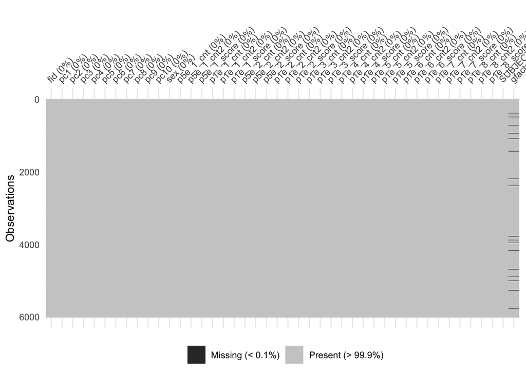

```r
baseline_test_tibble <- baseline_test_gfactor %>% do.call(rbind,.)

General_Cognitive_Function_Davies_gfactor <- left_join(General_Cognitive_Function_Davies,
                                                       baseline_test_tibble, by="SUBJECTKEY")

naniar::vis_miss(General_Cognitive_Function_Davies_gfactor)
```

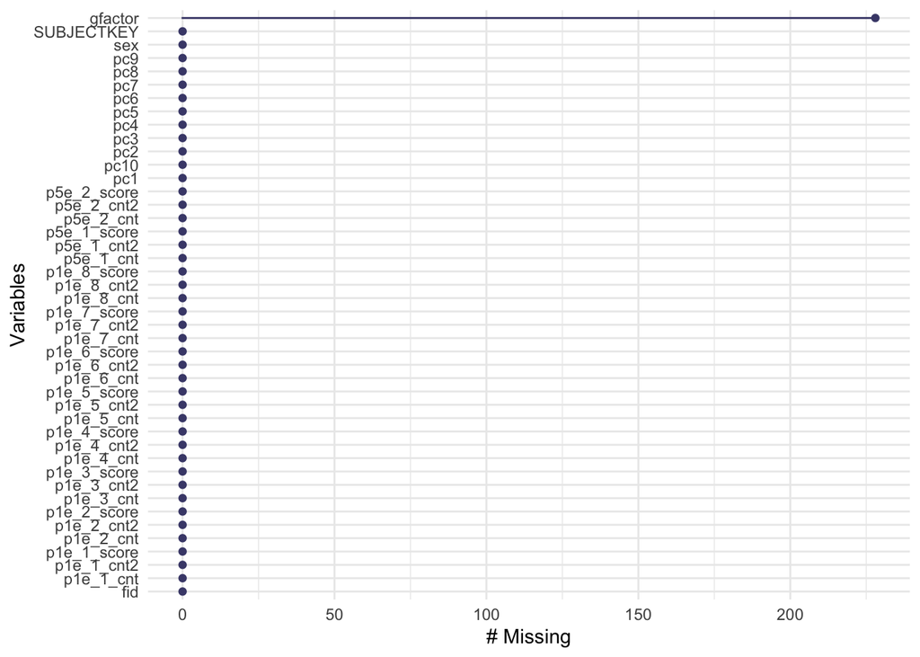

```r
naniar::gg_miss_var(General_Cognitive_Function_Davies_gfactor)
```

After joining with gfactor, around 3.79% of the subjects are dropped because of the missing data in gfactor.

## 3.3 Join the loaded gfactor data and the computed genes

```r
genetics_gfactor_baseline_train <-map2(.x=genetics_score_train_data,.y =baseline_train_gfactor,~full_join(.x,.y,by="SUBJECTKEY")%>%
                                    drop_na())

genetics_gfactor_baseline_test <- map2(.x=genetics_score_test_data,.y =baseline_test_gfactor,~full_join(.x,.y,by="SUBJECTKEY")%>%
                                    drop_na())

genetics_gfactor_followup_train <- map2(.x=genetics_score_train_data,.y =followup_train_gfactor,~full_join(.x,.y,by="SUBJECTKEY")%>%
                                    drop_na())

genetics_gfactor_followup_test <- map2(.x=genetics_score_test_data,.y =followup_test_gfactor,~full_join(.x,.y,by="SUBJECTKEY")%>%
                                    drop_na())

genetics_gfactor_baseline_train_select <- genetics_gfactor_baseline_train %>% map(.,~select(.,-all_of(c("SUBJECTKEY","SITE_ID_L"))))

genetics_gfactor_baseline_test_select <- genetics_gfactor_baseline_test%>% map(.,~select(.,-all_of(c("SUBJECTKEY","SITE_ID_L"))))

genetics_gfactor_followup_train_select <- genetics_gfactor_followup_train%>% map(.,~select(.,-all_of(c("SUBJECTKEY","SITE_ID_L"))))

genetics_gfactor_followup_test_select <- genetics_gfactor_followup_test%>% map(.,~select(.,-all_of(c("SUBJECTKEY","SITE_ID_L"))))
```

## 3.4 compute residuals against all the pc scores

```r
### In the scale method, baseline mean and sd is used to scale the followup.



genetics_pc_residual_computing <- function(data_input = genetics_gfactor_baseline_train[[1]],
                                           gene_score_name = genetics_cog_score_feature_names[[1]]){
  ## write the formula according to the score selected
  pc_score_string <- paste("pc1","pc2","pc3","pc4", sep = "+")
  General_Cognitive_Function_Davies_formula <- paste0(gene_score_name[1],"~",pc_score_string)%>% as.formula()
  General_Cognitive_Function_Savage_formula <- paste0(gene_score_name[2],"~",pc_score_string)%>% as.formula()
  Cognitive_Performance_lee_formula <- paste0(gene_score_name[3],"~",pc_score_string)%>% as.formula()
  ### linear regression model, the residuals have mean close to 0
  General_Cognitive_Function_Davies_mod <- lm(General_Cognitive_Function_Davies_formula,data = data_input)
  General_Cognitive_Function_Savage_mod <- lm(General_Cognitive_Function_Savage_formula,data = data_input)
  Cognitive_Performance_lee_mod <- lm(Cognitive_Performance_lee_formula,data = data_input)
  ### get the residuals
  General_Cognitive_Function_Davies_residuals <- General_Cognitive_Function_Davies_mod%>% residuals()%>%scale()
  General_Cognitive_Function_Savage_residuals <- General_Cognitive_Function_Savage_mod%>% residuals()%>%scale()
  Cognitive_Performance_lee_residuals <- Cognitive_Performance_lee_mod%>% residuals()%>%scale()
### save the output
output_data_all <-data_input%>% mutate(General_Cognitive_Function_Davies_residuals=
                                         General_Cognitive_Function_Davies_residuals,
                                       General_Cognitive_Function_Savage_residuals=
                                         General_Cognitive_Function_Savage_residuals,
                                       Cognitive_Performance_lee_residuals=
                                         Cognitive_Performance_lee_residuals)
  output_data_select <- output_data_all %>% dplyr::select("gfactor",ends_with("residuals"))
  return(list(data_all = output_data_all,data_select = output_data_select))
}



genetics_gfactor_residual_baseline_train <- map2(.x = genetics_gfactor_baseline_train,
                                                 .y = genetics_cog_score_feature_names,
                                        ~genetics_pc_residual_computing(data_input = .x,gene_score_name = .y))
genetics_gfactor_residual_baseline_train_select <- map(genetics_gfactor_residual_baseline_train,
                                                       "data_select")

genetics_gfactor_residual_baseline_test <- map2(.x = genetics_gfactor_baseline_test,
                                                 .y = genetics_cog_score_feature_names,
                                        ~genetics_pc_residual_computing(data_input = .x,gene_score_name = .y))
genetics_gfactor_residual_baseline_test_select <- map(genetics_gfactor_residual_baseline_test,
                                                      "data_select")

genetics_gfactor_residual_followup_train<- map2(.x = genetics_gfactor_followup_train,
                                                 .y = genetics_cog_score_feature_names,
                                        ~genetics_pc_residual_computing(data_input = .x,gene_score_name = .y))


genetics_gfactor_residual_followup_train_select <- map(genetics_gfactor_residual_followup_train,
                                                       "data_select")

genetics_gfactor_residual_followup_test<- map2(.x = genetics_gfactor_followup_test,
                                                 .y = genetics_cog_score_feature_names,
                                        ~genetics_pc_residual_computing(data_input = .x,gene_score_name = .y))


genetics_gfactor_residual_followup_test_select <- map(genetics_gfactor_residual_followup_test,
                                                      "data_select")


residual_features <- c("General_Cognitive_Function_Davies_residuals",
                       "General_Cognitive_Function_Savage_residuals",
                       "Cognitive_Performance_lee_residuals")
```

# 4 modelling

```r
### formula and recipe
recipe_prep_gene <- function(train_input=train_gfactor_scan_enet,feature_input){
  norm_recipe <- recipe( as.formula("gfactor~."), data = train_input) %>%
update_role(all_of(feature_input), new_role = "predictor")%>%
  update_role("gfactor", new_role = "outcome" )%>%
  step_dummy(all_nominal()) %>%
  prep(training = train_input, retain = TRUE)
  return(norm_recipe)
}
```

## 4.1 Performance of baseline

```r
### fit the enet model
### baseline
baseline_recipe_list <- map(.x = genetics_gfactor_residual_baseline_train_select,
                             ~recipe_prep_gene(train_input=.x, feature_input = residual_features))

enet_fit_baseline <- baseline_recipe_list %>% map(.,~enet_tuning(recipe_input = .))

enet_fit_wf <- map(enet_fit_baseline,"enet_wf_final")


enet_pred_baseline <- pmap(list(baseline_recipe_list,enet_fit_wf,
                                genetics_gfactor_residual_baseline_test_select),~
                                                 model_final_fit(recipe_input = ..1,
                                    wf_input = ..2,
                                    test_data = ..3))





enet_pred_baseline_results <- map(enet_pred_baseline,"model_predict")

enet_pred_baseline_train <- pmap(list(baseline_recipe_list,enet_fit_wf,
                                      genetics_gfactor_residual_baseline_train_select),~
                                                 model_final_fit(recipe_input = ..1,
                                    wf_input = ..2,
                                    test_data = ..3))





enet_pred_baseline_results_train <- map(enet_pred_baseline_train,"model_predict")

enet_baseline_metric <- purrr::map2(.x=enet_pred_baseline_results,
                                .y=genetics_gfactor_baseline_test,
                                ~metric_compute_site(data_input =.x ,
                                           site_input = .y)) %>%
                      do.call(rbind,.)

      enet_baseline_metric%>%
    kableExtra::kbl(caption = "metrics for all sites in baseline") %>%
    kableExtra::kable_classic(full_width = F,
                             html_font = "Cambria")
```

metrics for all sites in baseline

| correlation | tradrsq | MAE | RMSE | site |
| --- | --- | --- | --- | --- |
| 0.2192893 | -0.2191925 | 0.7409774 | 0.9029551 | site01 |
| 0.2540891 | 0.0541927 | 0.7192816 | 0.9300267 | site02 |
| 0.3444221 | 0.0313937 | 0.5961941 | 0.7993466 | site03 |
| 0.3375733 | 0.1054992 | 0.6836764 | 0.8544234 | site04 |
| 0.2793382 | 0.0700389 | 0.6409305 | 0.7811757 | site05 |
| 0.2619934 | 0.0224283 | 0.7404577 | 0.9341441 | site06 |
| 0.2502449 | 0.0448504 | 0.6366540 | 0.7983489 | site07 |
| 0.1423274 | -0.0048915 | 0.6975549 | 0.9134799 | site08 |
| 0.2756640 | 0.0710542 | 0.7612926 | 0.9591978 | site09 |
| 0.2828449 | 0.0370720 | 0.7101005 | 0.8918307 | site10 |
| 0.1979714 | 0.0216687 | 0.6629138 | 0.8409591 | site11 |
| 0.2774559 | 0.0331267 | 0.6490772 | 0.8438546 | site12 |
| 0.2516319 | 0.0626261 | 0.6566181 | 0.8636499 | site13 |
| 0.2618536 | 0.0175563 | 0.7716369 | 0.9697259 | site14 |
| 0.1771685 | -0.1460795 | 0.7334953 | 0.8877764 | site15 |
| 0.2105712 | -0.0008414 | 0.7716852 | 0.9880370 | site16 |
| 0.3415786 | 0.0334434 | 0.7850438 | 0.9930543 | site17 |
| 0.1471050 | -0.0072136 | 0.7240304 | 0.9377964 | site18 |
| 0.2544141 | 0.0637384 | 0.6680051 | 0.8481696 | site19 |
| 0.2677263 | 0.0610343 | 0.6259769 | 0.7965539 | site20 |
| 0.2720424 | 0.0635079 | 0.6432444 | 0.8214908 | site21 |

```r
enet_baseline_metric_avg <- average_metric_one_mod(metric_list =enet_baseline_metric)

enet_baseline_metric_avg_table <- enet_baseline_metric_avg %>%
  mutate_if(is.numeric, round, digits=3)%>%
  mutate("correlation (sd)" = paste0(correlation," (",cor_sd,")"))%>%
  mutate("tradrsq (sd)" = paste0(tradrsq," (",rsq_sd,")"))%>%
  mutate("MAE (sd)" = paste0(MAE," (",mae_sd,")"))%>%
  mutate("RMSE (sd)" = paste0(RMSE," (",rmse_sd,")"))%>%
  select_if(is.character)

avg_table_var_names <- c("correlation (sd)", "tradrsq (sd)","MAE (sd)","RMSE (sd)"  )

  enet_baseline_metric_avg_table%>%
    dplyr::select(all_of(avg_table_var_names))%>%
    kableExtra::kbl(caption = paste0("metrics for modalities averaged across sites in baseline")) %>%
    kableExtra::kable_classic(full_width = F,
                             html_font = "Cambria")
```

metrics for modalities averaged across sites in baseline

| correlation (sd) | tradrsq (sd) | MAE (sd) | RMSE (sd) |
| --- | --- | --- | --- |
| 0.253 (0.056) | 0.02 (0.074) | 0.696 (0.055) | 0.884 (0.066) |

## 4.2 Performance of followup

```r
### fit the enet model
### followup
followup_recipe_list <- map(.x=genetics_gfactor_residual_followup_train_select,
                             ~recipe_prep_gene(train_input=.x,feature_input = residual_features))

enet_fit_followup <- followup_recipe_list %>% map(.,~enet_tuning(recipe_input = .))

enet_fit_wf_followup <- map(enet_fit_followup,"enet_wf_final")


enet_pred_followup <- pmap(list(followup_recipe_list,enet_fit_wf_followup,
                                genetics_gfactor_residual_followup_test_select),~
                                                 model_final_fit(recipe_input = ..1,
                                    wf_input = ..2,
                                    test_data = ..3))

enet_pred_followup_results <- map(enet_pred_followup,"model_predict")


enet_pred_followup_train <- pmap(list(followup_recipe_list,enet_fit_wf_followup,
                                      genetics_gfactor_residual_followup_train_select),~
                                                 model_final_fit(recipe_input = ..1,
                                    wf_input = ..2,
                                    test_data = ..3))

enet_pred_followup_results_train <- map(enet_pred_followup_train,"model_predict")

enet_followup_metric <- purrr::map2(.x=enet_pred_followup_results,
                                .y=genetics_gfactor_followup_test,
                                ~metric_compute_site(data_input =.x ,
                                           site_input = .y)) %>%
                      do.call(rbind,.)

      enet_followup_metric%>%
    kableExtra::kbl(caption = "metrics for all sites in followup") %>%
    kableExtra::kable_classic(full_width = F,
                             html_font = "Cambria")
```

metrics for all sites in followup

| correlation | tradrsq | MAE | RMSE | site |
| --- | --- | --- | --- | --- |
| 0.1046772 | -0.1988852 | 0.5975172 | 0.7354948 | site01 |
| 0.2409468 | 0.0496127 | 0.7449792 | 0.9414265 | site02 |
| 0.2846991 | 0.0446309 | 0.6561265 | 0.8464938 | site03 |
| 0.3533759 | 0.0918298 | 0.7395620 | 0.9304573 | site04 |
| 0.3494769 | 0.1179252 | 0.6289871 | 0.7847494 | site05 |
| 0.3083850 | 0.0666775 | 0.6248301 | 0.8129433 | site06 |
| 0.0162126 | -0.1055476 | 0.5866553 | 0.7212057 | site07 |
| 0.0768175 | -0.0467408 | 0.6921190 | 0.8911437 | site08 |
| 0.2667123 | 0.0467836 | 0.7176184 | 0.8986539 | site09 |
| 0.3268314 | -0.0647669 | 0.6615231 | 0.8709315 | site10 |
| 0.1974753 | 0.0244380 | 0.7294083 | 0.9129785 | site11 |
| 0.2023919 | 0.0112101 | 0.6095311 | 0.7920423 | site12 |
| 0.2701827 | 0.0715036 | 0.6254429 | 0.7991374 | site13 |
| 0.3048901 | 0.0671689 | 0.7364454 | 0.9268455 | site14 |
| 0.1856361 | -0.0179701 | 0.7154051 | 0.9161310 | site15 |
| 0.2350639 | 0.0502173 | 0.7191414 | 0.9301480 | site16 |
| 0.2950537 | 0.0801191 | 0.6985695 | 0.9021019 | site17 |
| 0.1557053 | 0.0125261 | 0.7149136 | 0.9026069 | site18 |
| 0.2713195 | 0.0562209 | 0.7181045 | 0.8851966 | site19 |
| 0.3166228 | 0.0828835 | 0.6176641 | 0.7736655 | site20 |
| 0.2656366 | 0.0621326 | 0.5810559 | 0.7478860 | site21 |

```r
enet_followup_metric_avg <- average_metric_one_mod(metric_list =enet_followup_metric)

enet_followup_metric_avg_table <- enet_followup_metric_avg %>%
  mutate_if(is.numeric, round, digits=3)%>%
  mutate("correlation (sd)" = paste0(correlation," (",cor_sd,")"))%>%
  mutate("tradrsq (sd)" = paste0(tradrsq," (",rsq_sd,")"))%>%
  mutate("MAE (sd)" = paste0(MAE," (",mae_sd,")"))%>%
  mutate("RMSE (sd)" = paste0(RMSE," (",rmse_sd,")"))%>%
  select_if(is.character)

  enet_followup_metric_avg_table%>%
    dplyr::select(all_of(avg_table_var_names))%>%
    kableExtra::kbl(caption = paste0("metrics for modalities averaged across sites in followup")) %>%
    kableExtra::kable_classic(full_width = F,
                             html_font = "Cambria")
```

metrics for modalities averaged across sites in followup

| correlation (sd) | tradrsq (sd) | MAE (sd) | RMSE (sd) |
| --- | --- | --- | --- |
| 0.239 (0.09) | 0.024 (0.075) | 0.672 (0.056) | 0.853 (0.072) |

## 4.3 feature importance for the elastic net models

### 4.3.1 elastic net coefficients

```r
enet_fit_baseline <- map(enet_pred_baseline,"model_final_fit")
enet_param_baseline <- map(enet_fit_baseline,~parsnip::tidy(.))


enet_fit_followup<- map(enet_pred_followup,"model_final_fit")
enet_param_followup <- map(enet_fit_followup,~parsnip::tidy(.))

identical(site_char, names(enet_param_baseline))
```

```
## [1] TRUE
```

### 4.3.2 Compute univariate correlation and correlation tests

Baseline

```r
corr_data_all <- rbind(genetics_gfactor_residual_baseline_train[[1]][["data_all"]],
                       genetics_gfactor_residual_baseline_test[[1]][["data_all"]])

 corr_all_features <- purrr::map(.x = residual_features,~cor(corr_data_all[[.x]],corr_data_all[["gfactor"]]))%>%
                                          do.call(rbind,.)%>% as.numeric()

 corr_all_features_cor_test <- purrr::map(.x = residual_features,
                            ~cor.test(corr_data_all[[.x]],corr_data_all[["gfactor"]],method="pearson"))

 corr_all_features_ci <- purrr::map(corr_all_features_cor_test,"conf.int")%>%
                                          do.call(rbind,.)%>% tibble::as_tibble()%>%
                                          rename(low=V1,upp=V2)
  corr_output_tibble <- tibble(feature_names = residual_features,value = corr_all_features)
corr_output_tibble <- cbind(corr_output_tibble,corr_all_features_ci)


plotting_names <- tibble(feature_names = corr_output_tibble$feature_names,
                         plotting_name = c("Davies PGS","Savage PGS", "Lee PGS"))

 corr_baseline_all_sites_names <- full_join(corr_output_tibble,plotting_names, by = "feature_names")
### get the names
```

Compute the univariate correlations at followup

```r
corr_data_all_followup <- rbind(genetics_gfactor_residual_followup_train[[1]][["data_all"]],
                       genetics_gfactor_residual_followup_test[[1]][["data_all"]])

 corr_all_features_followup <- purrr::map(.x = residual_features,
                                          ~cor(corr_data_all_followup[[.x]],
                                               corr_data_all_followup[["gfactor"]]))%>%
                                          do.call(rbind,.)%>% as.numeric()

 corr_all_features_cor_test_followup <- purrr::map(.x = residual_features,
                            ~cor.test(corr_data_all_followup[[.x]],
                                      corr_data_all_followup[["gfactor"]],method="pearson"))

 corr_all_features_ci_followup <- purrr::map(corr_all_features_cor_test_followup,"conf.int")%>%
                                          do.call(rbind,.)%>% tibble::as_tibble()%>%
                                          rename(low=V1,upp=V2)



  corr_output_tibble_followup <- tibble(feature_names = residual_features,
                                        value = corr_all_features_followup)
corr_output_tibble_followup <- cbind(corr_output_tibble_followup,corr_all_features_ci_followup)


 corr_followup_all_sites_names <- full_join(corr_output_tibble_followup,
                                            plotting_names, by = "feature_names")
```

Tidying up the output

```r
processed_coefs_baseline <- coef_processing(list_input = enet_param_baseline)
processed_coefs_followup <- coef_processing(list_input = enet_param_followup)
### get better names
### Join the feature names with plotting names
processed_coefs_baseline <- processed_coefs_baseline %>% rename( feature_names= term)
processed_coefs_baseline_with_names <- full_join(processed_coefs_baseline,
                                            plotting_names, by = "feature_names")


processed_coefs_followup <- processed_coefs_followup %>% rename( feature_names= term)
processed_coefs_followup_with_names <- full_join(processed_coefs_followup,
                                            plotting_names, by = "feature_names")
```

### 4.3.3 Elastic net feature importance with dots

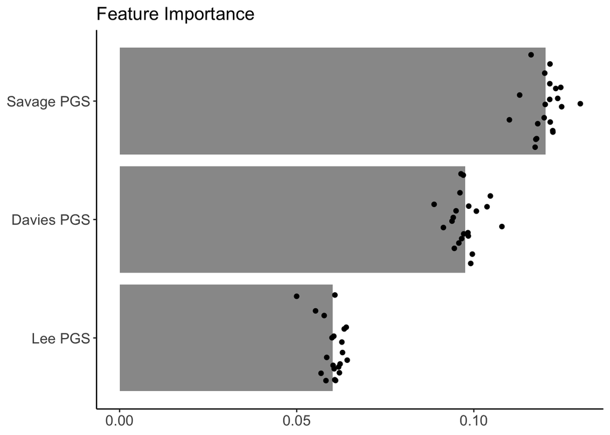

```r
mean_total_bar_plot_with_dots <- function(data_input,site_mean_input="mean"){
    estimate_name <- paste0(site_mean_input,"_estimate")
  ### arrange the data from small to large
  data_input <- data_input %>%
            #    select(all_of(c("plotting_name",estimate_name)))%>%
                arrange(.data[[estimate_name]])
  ordered_plotting_names <- data_input$plotting_name
  data_input<- data_input%>%
                  mutate(plotting_name = as.factor(plotting_name))%>%
                  mutate(plotting_name = factor(plotting_name,
                                                      levels =ordered_plotting_names))

  data_input_longer <- data_input %>%
                       select(-all_of(c("feature_names","mean_estimate")))%>%
                       pivot_longer(!plotting_name, values_to = "site_estimates",names_to = "site")



    bar_plot <- ggplot() +
  geom_bar(aes(x=data_input[[estimate_name]], y=data_input[["plotting_name"]]),stat="identity",fill = "grey60")+
  geom_jitter(aes(x=data_input_longer[["site_estimates"]], y=data_input_longer[["plotting_name"]]))+
  theme_classic() +
    labs(title = "Feature Importance")+
theme(
  axis.title.x = element_blank(),
  axis.text.x = element_text(size = 12),
  axis.title.y = element_blank(),
  axis.text.y = element_text(size = 12),
  legend.text = element_blank(),
  plot.title = element_text(size=15))
  return(list(bar_plot=bar_plot,
              ordered_plotting_names=ordered_plotting_names))
}

enet_bar_baseline_with_dots <-  mean_total_bar_plot_with_dots(data_input = processed_coefs_baseline_with_names)

enet_bar_baseline_with_dots[["bar_plot"]]
```

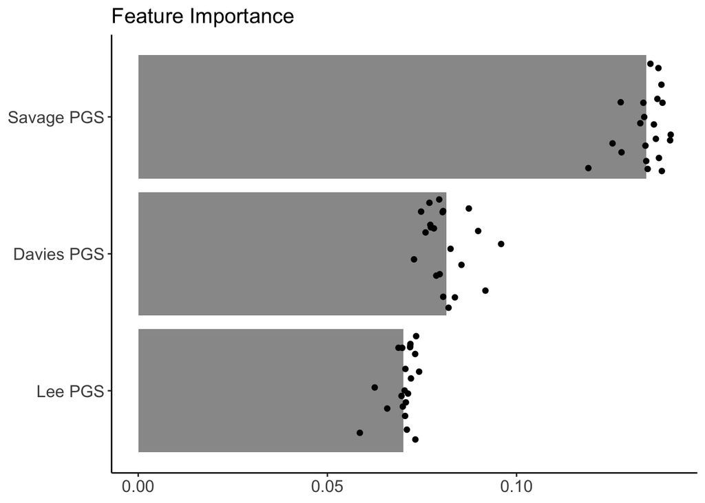

```r
enet_bar_followup_with_dots <-  mean_total_bar_plot_with_dots(data_input = processed_coefs_followup_with_names)

enet_bar_followup_with_dots[["bar_plot"]]
```

### 4.3.4 plotting univariate correlations

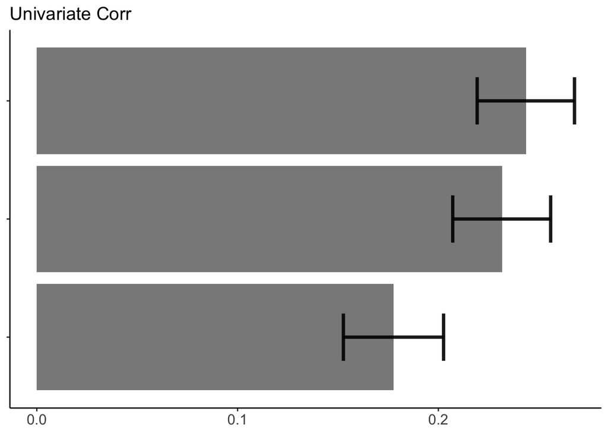

```r
#corr_baseline_all_sites_names <- corr_output_tibble %>% mutate(plotting_name = feature_names)


corr_baseline_bar <-   corr_baseline_all_sites_names%>%
     mutate(plotting_name = as.factor(plotting_name))%>%
                  mutate(plotting_name = factor(plotting_name,
                                  levels =enet_bar_baseline_with_dots[["ordered_plotting_names"]]))%>%
 #mutate(plotting_name = fct_reorder(plotting_name, value,.fun = "max"))%>%
  ggplot(aes(x = plotting_name, y = value))+
    geom_bar(stat = "identity",fill="gray30",alpha = 0.7)+
    geom_errorbar( aes(x=plotting_name,
                   ymin=low,
                   ymax=upp),
               width=0.4, colour="black", alpha=0.9, linewidth=1.3)+
      coord_flip()+
    theme_classic() +
  labs(title = "Univariate Corr") +
   theme(
  axis.title.x = element_blank(),
  axis.text.x = element_text(size = 12),
  axis.title.y = element_blank(),
  axis.text.y = element_blank(),
  legend.text = element_blank(),
  plot.title = element_text(size=15))


corr_baseline_bar
```

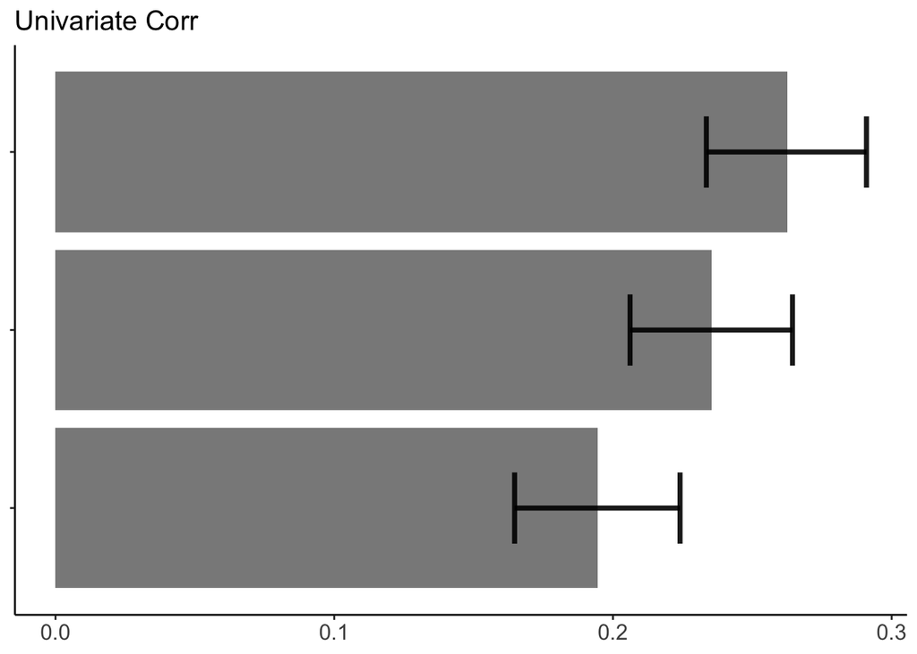

```r
### get the names

#corr_baseline_all_sites_names <- corr_output_tibble %>% mutate(plotting_name = feature_names)


corr_followup_bar <-  corr_followup_all_sites_names%>%
   mutate(plotting_name = as.factor(plotting_name))%>%
                  mutate(plotting_name = factor(plotting_name,
                                  levels =enet_bar_followup_with_dots[["ordered_plotting_names"]]))%>%
 #mutate(plotting_name = fct_reorder(plotting_name, value,.fun = "max"))%>%
  ggplot(aes(x = plotting_name, y = value))+
    geom_bar(stat = "identity",fill="gray30",alpha = 0.7)+
    geom_errorbar( aes(x=plotting_name,
                   ymin=low,
                   ymax=upp),
               width=0.4, colour="black", alpha=0.9, linewidth=1.3)+
      coord_flip()+
    theme_classic() +
  labs(title = "Univariate Corr") +
    theme(
  axis.title.x = element_blank(),
  axis.text.x = element_text(size = 12),
  axis.title.y = element_blank(),
  axis.text.y = element_blank(),
  legend.text = element_blank(),
  plot.title = element_text(size=15))


corr_followup_bar
```

combine the plots together

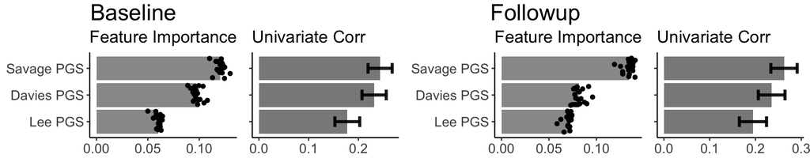

```r
aligned_baseline_all <-ggpubr::ggarrange(enet_bar_baseline_with_dots[["bar_plot"]],
                                                   corr_baseline_bar,
                                                   nrow = 1, ncol = 2,widths = c(1.5,1)) %>%
                            ggpubr::annotate_figure(top = ggpubr::text_grob("Baseline",size=20,hjust=1.3))


aligned_followup_all <-ggpubr::ggarrange(enet_bar_followup_with_dots[["bar_plot"]],
                                                   corr_followup_bar,
                                                   nrow = 1, ncol = 2,widths = c(1.5,1))%>%
                            ggpubr::annotate_figure(top = ggpubr::text_grob("Followup",size=20,hjust=1.3))
aligned_plots_all <- ggpubr::ggarrange(aligned_baseline_all,
                                                   aligned_followup_all,
                                                   nrow = 1, ncol = 2)
aligned_plots_all
```

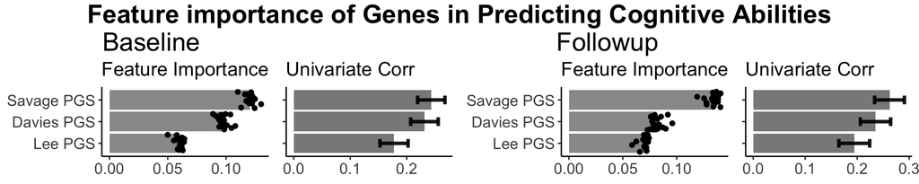

```r
title_plot_all <- ggpubr::annotate_figure(aligned_plots_all,
                        top = ggpubr::text_grob("Feature importance of Genes in Predicting Cognitive Abilities",size=20, face = "bold"))

title_plot_all
```

## 4.4 save the output

```r
output_list <- list(baseline_train_pred = enet_pred_baseline_results_train,
                    baseline_test_pred = enet_pred_baseline_results,
                    baseline_train_data = genetics_gfactor_baseline_train,
                    baseline_test_data = genetics_gfactor_baseline_test,
                    followup_train_pred = enet_pred_followup_results_train,
                    followup_test_pred = enet_pred_followup_results,
                    followup_train_data =genetics_gfactor_followup_train ,
                    followup_test_data = genetics_gfactor_followup_test)
```

```r
saveRDS(output_list,paste0(scriptfold,'genetics_psychopathology_common_scan_all_scripts/psychopathology_cog_gene_pred_residual', '.RData'))
```

```r
enet_baseline_metric_output_table <-  enet_baseline_metric_avg_table%>%
                                      mutate(event = "baseline")


enet_followup_metric_output_table  <- enet_followup_metric_avg_table%>%
                                      mutate(event = "followup")

output_table <- bind_rows(enet_baseline_metric_output_table,
                          enet_followup_metric_output_table)%>%
                          mutate(modality = "Genes")
```

```r
saveRDS(output_table,paste0(scriptfold,'Common_psy_gene_brain_all/saved_outputs/performance_metrics/gene_performance_metric', '.RData'))
```